# Chapter 07

Josip Kovač

2022-07-31

# 1 Exercise 01

> Half-hourly electricity demand for Victoria, Australia is contained in vic_elec. Extract the January 2014 electricity demand, and aggregate this data to daily with daily total demands and maximum temperatures.

```r
jan14_vic_elec <- vic_elec %>%
  filter(yearmonth(Time) == yearmonth("2014 Jan")) %>%
  index_by(Date = as_date(Time)) %>%
  summarise(
    Demand = sum(Demand),
    Temperature = max(Temperature)
  )
```

> 1. Plot the data and find the regression model for Demand with temperature as a predictor variable. Why is there a positive relationship?

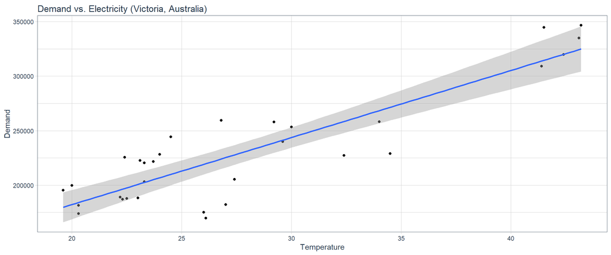

```
## Series: Demand
## Model: TSLM
##
## Residuals:
##      Min       1Q   Median       3Q      Max
## -49978.2 -10218.9   -121.3  18533.2  35440.6
##
## Coefficients:
##             Estimate Std. Error t value Pr(>|t|)
## (Intercept)  59083.9    17424.8   3.391  0.00203 **
## Temperature   6154.3      601.3  10.235 3.89e-11 ***
## ---
## Signif. codes:  0 '***' 0.001 '**' 0.01 '*' 0.05 '.' 0.1 ' ' 1
##
## Residual standard error: 24540 on 29 degrees of freedom
## Multiple R-squared: 0.7832,  Adjusted R-squared: 0.7757
## F-statistic: 104.7 on 1 and 29 DF, p-value: 3.8897e-11
```

There is a positive relationship since the hotter it gets, the more electricity gets spent on cooling (air conditioners etc.).

> 2. Produce a residual plot. Is the model adequate? Are there any outliers or influential observations?

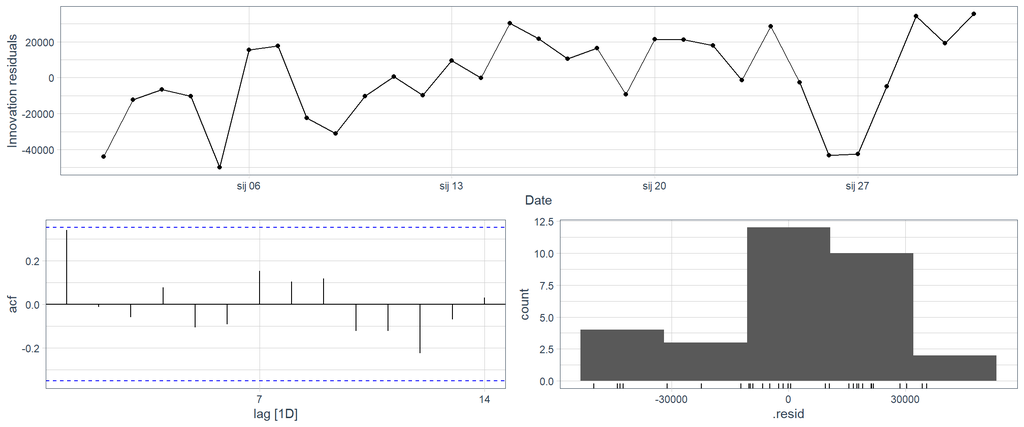

```
##
##  Shapiro-Wilk normality test
##
## data:  .
## W = 0.93736, p-value = 0.06978
```

The model is adequate since the errors are uncorrelated and are mostly normally distributed (Shapiro–Wilk test gives p-value of 0.06978). There are no outliers.

> Use the model to forecast the electricity demand that you would expect for the next day if the maximum temperature was 15$^\circ$C and compare it with the forecast if the with maximum temperature was 35$^\circ$C . Do you believe these forecasts? The following R code will get you started:

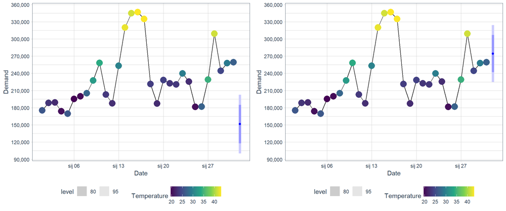

```r
plot_forecast <- function(target_temp) {
    out <- fit_lm %>%
  forecast(
    new_data(jan14_vic_elec, 1) %>%
      mutate(Temperature = target_temp)
  ) %>%
  autoplot(jan14_vic_elec) +
        geom_point(aes(color = Temperature, x = Date, y = Demand), size = 5) +
        scale_color_viridis_c() +
        scale_y_continuous(limits = c(100e3, 350e3),
                           labels = scales::comma_format(),
                           n.breaks = 10)

    return(out)
}

cowplot::plot_grid(
    plot_forecast(15),
    plot_forecast(35)
)
```

```r
jan14_vic_elec %>%
    as_tibble() %>%
    arrange(Temperature)
```

```
## # A tibble: 31 × 3
##    Date        Demand Temperature
##    <date>       <dbl>       <dbl>
##  1 2014-01-06 195241.        19.6
##  2 2014-01-07 199770.        20
##  3 2014-01-04 173798.        20.3
##  4 2014-01-25 181466.        20.3
##  5 2014-01-03 189086.        22.2
##  6 2014-01-19 187126.        22.3
##  7 2014-01-24 225570.        22.4
##  8 2014-01-12 187661.        22.5
##  9 2014-01-02 188351.        23
## 10 2014-01-21 222492.        23.1
## # … with 21 more rows
## # ℹ Use `print(n = ...)` to see more rows
```

The forecast for first plot seems dodgy, since the value of Temperature = 15 was never seen in the data. Therefore, we are extrapolating. Let’s see the predicted values for a range of numbers:

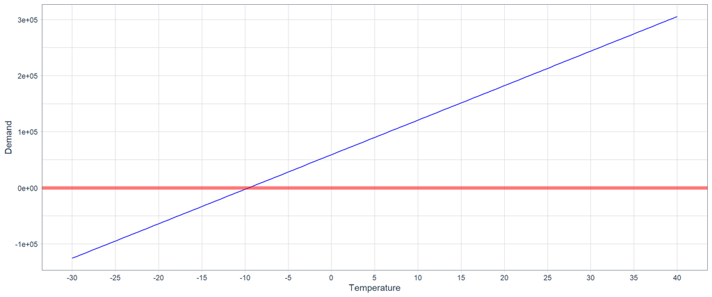

I doubt that people will not use electricity when it is cold. :)

> Give prediction intervals for your forecasts.

```
## When the temperature is 15*C, on average we can expect total electricity demand of 151.398 MWH. We can 95% sure that the demand will be between 100.179 and 202.617 MWH.
##
## When the temperature is 35*C, on average we can expect total electricity demand of 274.484 MWH. We can 95% sure that the demand will be between 224.939 and 324.029 MWH.
```

> Plot Demand vs Temperature for all of the available data in `vic_elec` aggregated to daily total demand and maximum temperature. What does this say about your model?

```
## Series: Demand
## Model: TSLM
##
## Residuals:
##       Min        1Q    Median        3Q       Max
## -62818.41 -13699.52    -25.83  17452.70 118947.95
##
## Coefficients:
##             Estimate Std. Error t value Pr(>|t|)
## (Intercept) 220345.8     2742.3  80.352   <2e-16 ***
## Temperature    172.0      125.9   1.366    0.172
## ---
## Signif. codes:  0 '***' 0.001 '**' 0.01 '*' 0.05 '.' 0.1 ' ' 1
##
## Residual standard error: 25470 on 1094 degrees of freedom
## Multiple R-squared: 0.001702,    Adjusted R-squared: 0.0007897
## F-statistic: 1.865 on 1 and 1094 DF, p-value: 0.17229
```

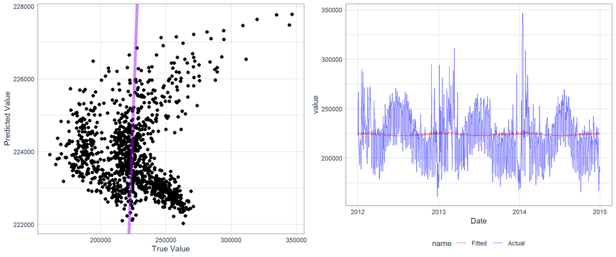

This tells me that the relationship between Demand and Temperature is non-linear. Linear model is not good for modelling this kind of relationship. There is also lots of seasonality present …

# 2 Exercise 02

> Data set `olympic_running` contains the winning times (in seconds) in each Olympic Games sprint, middle-distance and long-distance track events from 1896 to 2016.
> 1. Plot the winning time against the year for each event. Describe the main features of the plot.

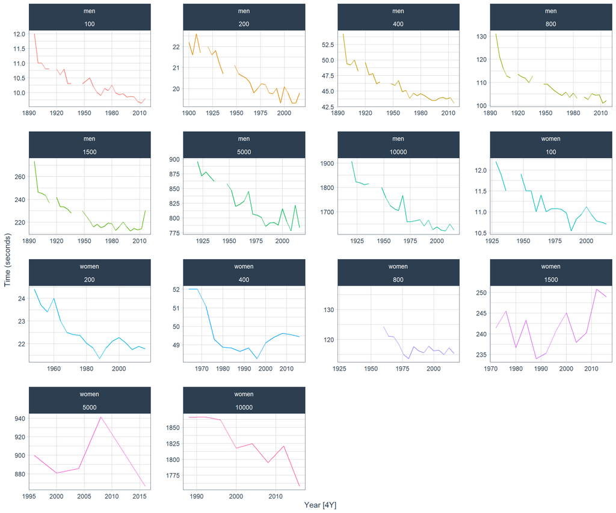

Gap is present in the data due to the WWII. Most series have downward trend. In some series we can see that the new winning records are actually worse than the past records.

> 2. Fit a regression line to the data for each event. Obviously the winning times have been decreasing, but at what average rate per year?

```
## # A tibble: 14 × 8
##    Length Sex   .model            term  estimate std.error statistic  p.value
##     <int> <chr> <chr>             <chr>    <dbl>     <dbl>     <dbl>    <dbl>
##  1  10000 women TSLM(Time ~ Year) Year   -3.50     0.701      -4.99  2.47e- 3
##  2  10000 men   TSLM(Time ~ Year) Year   -2.67     0.192     -13.9   2.37e-12
##  3   5000 men   TSLM(Time ~ Year) Year   -1.03     0.104      -9.88  1.50e- 9
##  4   1500 men   TSLM(Time ~ Year) Year   -0.315    0.0418     -7.54  5.23e- 8
##  5   5000 women TSLM(Time ~ Year) Year   -0.303    1.73       -0.175 8.69e- 1
##  6    800 women TSLM(Time ~ Year) Year   -0.198    0.0384     -5.16  1.45e- 4
##  7    800 men   TSLM(Time ~ Year) Year   -0.152    0.0177     -8.58  6.47e- 9
##  8    400 men   TSLM(Time ~ Year) Year   -0.0646   0.00586   -11.0   2.75e-11
##  9    400 women TSLM(Time ~ Year) Year   -0.0401   0.0170     -2.35  3.65e- 2
## 10    200 women TSLM(Time ~ Year) Year   -0.0336   0.00568    -5.92  2.17e- 5
## 11    200 men   TSLM(Time ~ Year) Year   -0.0249   0.00181   -13.7   3.80e-13
## 12    100 women TSLM(Time ~ Year) Year   -0.0142   0.00187    -7.58  3.72e- 7
## 13    100 men   TSLM(Time ~ Year) Year   -0.0126   0.00120   -10.5   7.24e-11
## 14   1500 women TSLM(Time ~ Year) Year    0.147    0.106       1.38  1.96e- 1
```

We can see the biggest downward trend in the category 10.000 / women: every year, the winning time is lower by 3.50 seconds on average. Unfortunately, in one of the series, winning times are actually increasing on average: 1.500 / women.

> 3. Plot the residuals against the year. What does this indicate about the suitability of the fitted lines?

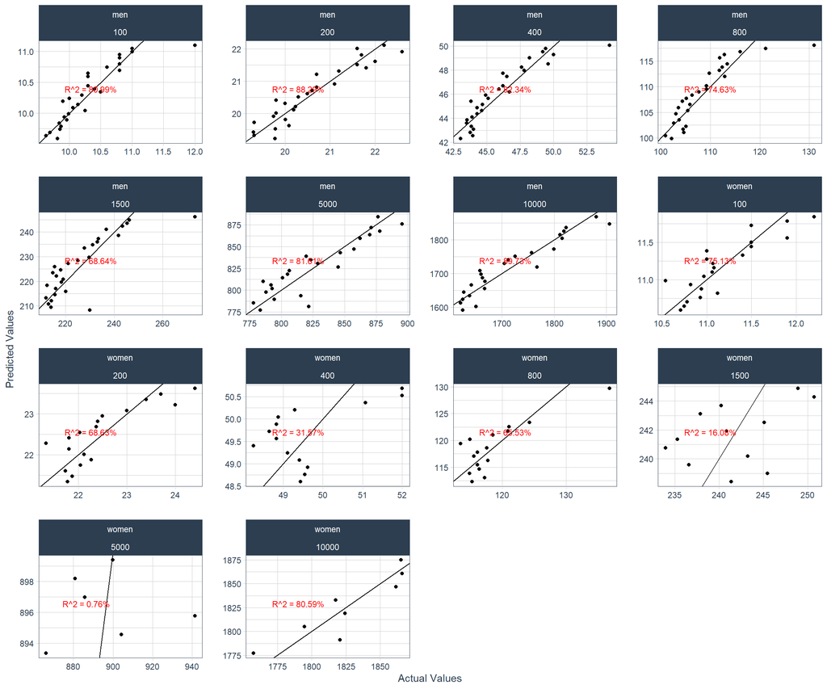

Most models are quite good (judging by the $R^2$), while the rest of the models need some improvement. Most worrisome is 5000 / women and 1500 / women.

> 4. Predict the winning time for each race in the 2020 Olympics. Give a prediction interval for your forecasts. What assumptions have you made in these calculations?

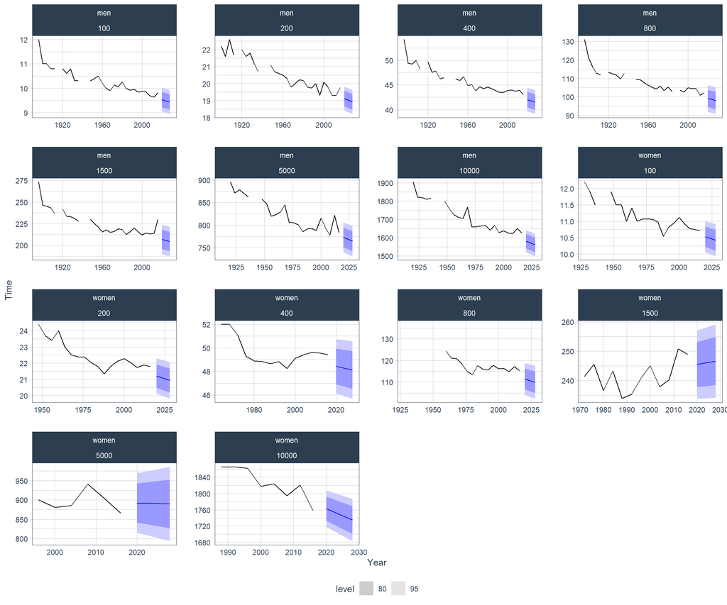

I’ve made a decision to forecast next 3 relevant years (2020, 2024, 2028). The problematic models identified earlier show neutral or positive trend, which is nonsensical.

Anyways, the assumption are:

- Model is a reasonable approximation to reality.
- Characteristics of residuals:
  - Mean of zero.
  - No autocorrelation.
  - They are unrelated to the predictor variables.
  - Useful feature: residuals are normally distributed with a constant variance of $\sigma^2$ in order to easily produce prediction intervals.
  - Each predictor $x$ is not a random variable. We are violation this assumption here since these are observational data. In the context of time series, we are not controlling for predictor $x$, we are observing it.

# 3 Exercise 03

> An elasticity coefficient is the ratio of the percentage change in the forecast variable ($y$) to the percentage change in the predictor variable ($x$). Mathematically, the elasticity is defined as $(dy / dx) \times (x/y)$. Consider the log-log model:

$$\log{y} = \beta_0 + \beta_1 \log{x} +
\epsilon$$

> Express $y$ as a function of $x$ and show that the coefficient $\beta_{1}$ is the elasticity coefficient.

Helpful links: [link_01](https://stats.stackexchange.com/questions/91636/how-to-obtain-the-elasticity-from-a-log-level-regression), [link_02](https://stats.stackexchange.com/questions/9913/elasticity-of-log-log-regression) and [link_03](https://stats.stackexchange.com/questions/240660/log-log-elasticities-estimation).

Solution - first, we ignore $\epsilon$ as unrelated to $y$, and then we can apply chain rule:

$$\frac{d \log{y}}{d \log{x}} = \frac{d
\log{y}}{d y} \frac{d y}{d x} \frac{d x}{d log x}$$

We apply derivation rules to relevant functions ([reminder](https://www.mathsisfun.com/calculus/derivatives-rules.html)):

$$\frac{d \log{y}}{d y} = \frac{1}{y}$$

$$\frac{d x}{d log x} = x$$
Applying these conclusions to the first equation yields us:

$$\frac{d \log{y}}{d \log{x}} = \frac{d
\log{y}}{d y} \frac{dy}{dx} \frac{dx}{d log x} = \frac{1}{y}
\frac{dy}{dx} x = \frac{dy}{dx} \frac{x}{y}$$

… which is exactly the definition of elasticity as mentioned in the exercise.

# 4 Exercise 04

# 5 Exercise 05

# 6 Exercise 06

# 7 Exercise 07